# Name: Tanner Woods

## Checking Panel Balance

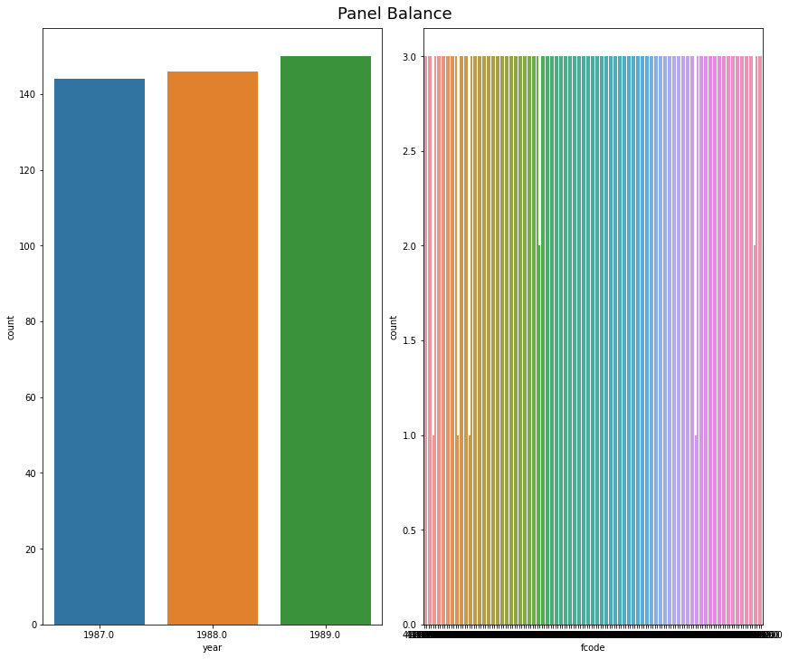

```python
fig, axes = plt.subplots(1, 2 , figsize=(12,10), constrained_layout = True)
fig.suptitle("Panel Balance", fontsize=18)

sns.countplot(x = 'year', data = Jtrain_Mdd, ax = axes[0])
sns.countplot(x = 'fcode', data = Jtrain_Mdd, ax = axes[1])

plt.show()
```

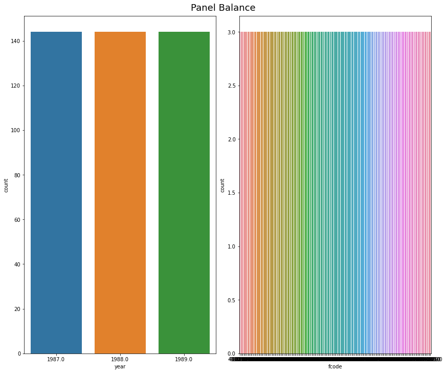

```python
counts_fcode = Jtrain_Mdd.groupby("fcode")["fcode"].transform(len)
mask = counts_fcode > 2

Jtrain_Mdd = Jtrain_Mdd[mask]

fig, axes = plt.subplots(1, 2 , figsize=(12,10), constrained_layout = True)
fig.suptitle("Panel Balance", fontsize=18)

sns.countplot(x = 'year', data = Jtrain_Mdd, ax = axes[0])
sns.countplot(x = 'fcode', data = Jtrain_Mdd, ax = axes[1])

plt.show()
```

## Identifying Unusual Observations

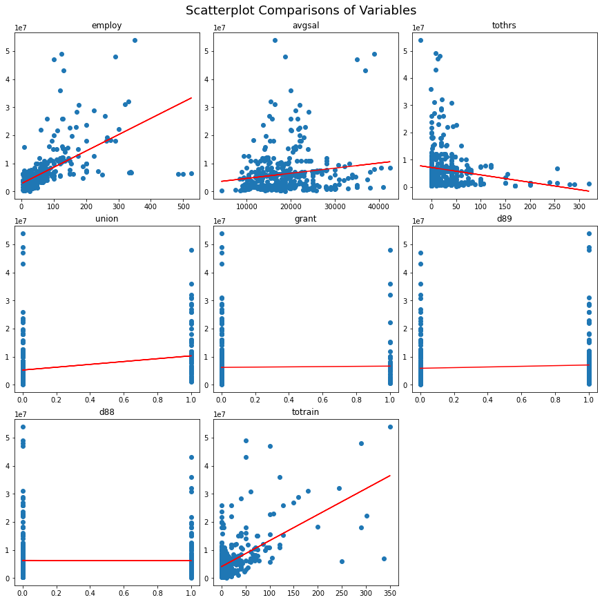

```python
## Predictor Scatterplots
fig, axes = plt.subplots(3, 3, figsize=(12,12), constrained_layout = True)
fig.suptitle("Scatterplot Comparisons of Variables", fontsize=18)
Temp = Jtrain_Mdd.iloc[:,2:]
Temp = Temp.drop(columns = 'sales')
Axis_x = 0
for i in range(0, len(Temp.columns)):
    Axis_y = i // 3
    if Axis_x > 2:
        Axis_x = 0
    axes[Axis_y,Axis_x].plot(Temp.iloc[:,i], Jtrain_Mdd['sales'], 'o')
    m, b = np.polyfit(Temp.iloc[:,i], Jtrain_Mdd['sales'], 1)
    axes[Axis_y,Axis_x].plot(Temp.iloc[:,i], m*Temp.iloc[:,i]+b, 'red')
    axes[Axis_y,Axis_x].set_title(Temp.columns[i])
    Axis_x +=1
fig.delaxes(axes[2][2])
plt.show()
```

## Transforming Predictors

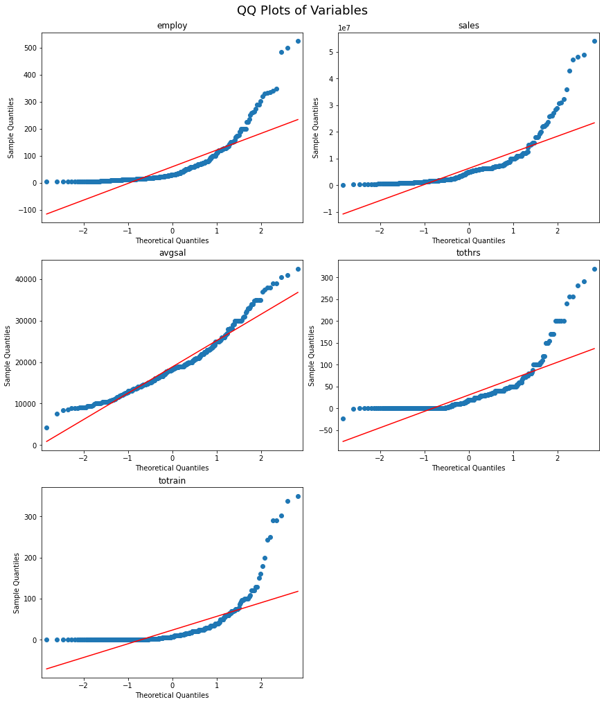

```python
## Visualizing predictor distributions via QQ Plots
Temp = Jtrain_Mdd.iloc[:,[2,3,4,5,10]]
fig, axes = plt.subplots (3, 2, figsize = (12,14), constrained_layout = True)
fig.suptitle("QQ Plots of Variables", fontsize = 18)
Axis_x = 0
for i in range (0, len(Temp.columns)):
    Axis_y = i // 2
    if Axis_x > 1:
            Axis_x = 0
    sm.qqplot(Temp.iloc[:,i], line='r', ax = axes[Axis_y, Axis_x])
    axes[Axis_y, Axis_x].set_title(Temp.columns[i])
    Axis_x +=1
fig.delaxes(axes[2][1])
plt.show()
```

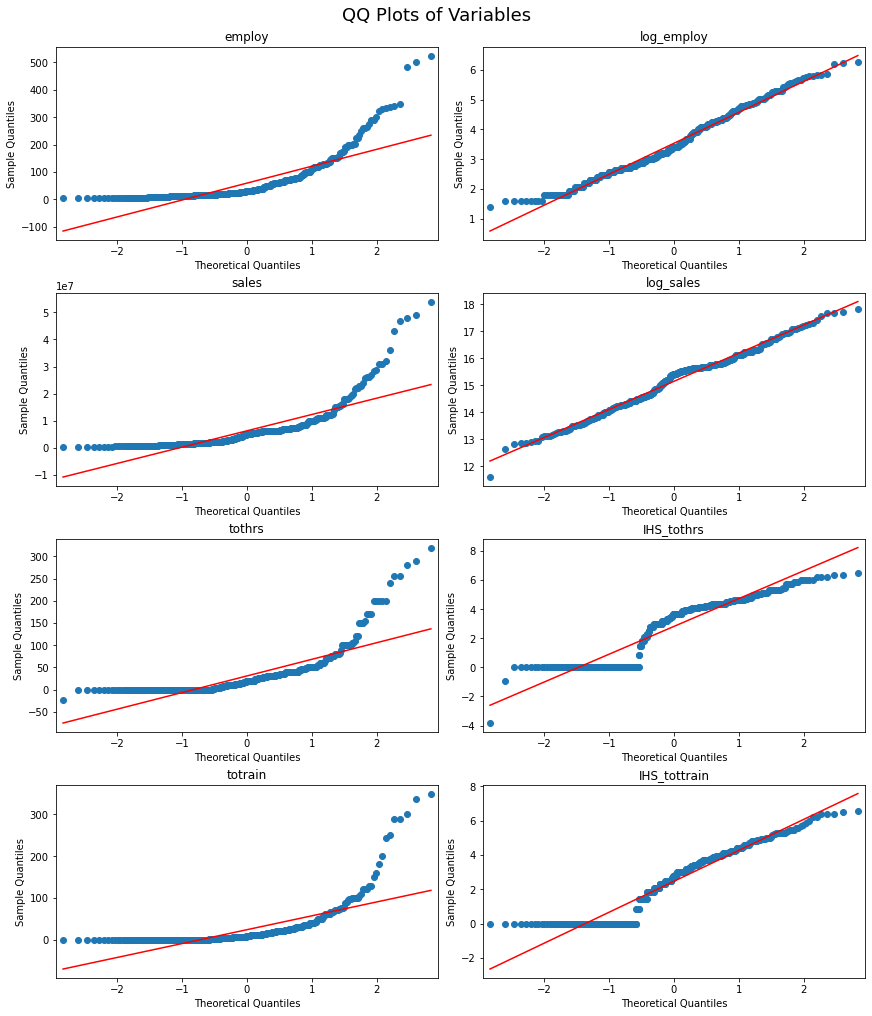

```python
## Jtrain_Transformation_Visualization := Jtrain_TV
Jtrain_TV = Jtrain_Mdd.copy()
Jtrain_TV = Jtrain_TV.iloc[:,[2,3,5,10]]

## Transforming quantitative predictors
## 'avgsal' -> Logarithm
## Remaining -> Inverse hyperbolic sine (due to natural zero points)
## Inserting transformation into comparison df
Jtrain_TV.insert(1, 'log_employ',
                 np.log(Jtrain_Mdd.iloc[:,2]))
Jtrain_TV.insert(3, 'log_sales',
                 np.log(Jtrain_Mdd.iloc[:,3]))
Jtrain_TV.insert(5, 'IHS_tothrs',
                 np.arcsinh(Jtrain_Mdd.iloc[:,5]))
Jtrain_TV.insert(7, 'IHS_tottrain',
                 np.arcsinh(Jtrain_Mdd.iloc[:,10]))

## Visualizing transformations via QQ Plots
fig, axes = plt.subplots (4, 2, figsize = (12,14), constrained_layout = True)
fig.suptitle("QQ Plots of Variables", fontsize = 18)
Axis_x = 0
for i in range (0, len(Jtrain_TV.columns)):
    Axis_y = i // 2
    if Axis_x > 1:
            Axis_x = 0
    sm.qqplot(Jtrain_TV.iloc[:,i], line='r', ax = axes[Axis_y, Axis_x])
    axes[Axis_y, Axis_x].set_title(Jtrain_TV.columns[i])
    Axis_x +=1
plt.show()
```

## Constructing Interaction Families

```python
## Baseline variable set
Jtrain_TV['avgsal'] = Jtrain_Mdd['avgsal']
Jtrain_Base = pd.concat([Jtrain_TV.iloc[:,[1,5,7,8]], Jtrain_Mdd.iloc[:,[6,7,8,9]]], axis = 1)
Jtrain_Base.insert(0, 'year', Jtrain_Mdd['year'])
Jtrain_Base.insert(1, 'fcode', Jtrain_Mdd['fcode'])
Jtrain_Base.insert(2, 'log_sales', Jtrain_TV['log_sales'])
Jtrain_Base.reset_index(drop = True, inplace = True)

## Variable subset to be run through poly.fit_transform()
Temp_Quant = Jtrain_TV.iloc[:,[1,5,7,8]]
Temp_Qualt = Jtrain_Mdd.iloc[:,[6,7,8,9]]
Temp_QuantQualt = pd.concat([Temp_Quant, Temp_Qualt], axis = 1)
```

```python
## Constructing family of squared regressors and regressor interactions
## Quantitative predictors: Interactions and second powers
poly = PolynomialFeatures(2)
Temp_QuantPoly = poly.fit_transform(Temp_Quant)
Temp_QuantInt = pd.DataFrame(data = Temp_QuantPoly,
                   columns = poly.get_feature_names(Temp_Quant.columns))
Temp_QuantInt = Temp_QuantInt.drop(columns = '1')

## Qualitative predictors: Interactions
poly = PolynomialFeatures(interaction_only = True)
Temp_QualtPoly = poly.fit_transform(Temp_Qualt)
Temp_QualtInt = pd.DataFrame(data = Temp_QualtPoly,
                   columns = poly.get_feature_names(Temp_Qualt.columns))
Temp_QualtInt = Temp_QualtInt.drop(columns = '1')

## Special case for quantitative*qualitative interactions
Temp_QuantQualtPoly = poly.fit_transform(Temp_QuantQualt)
Temp_QuantQualtInt = pd.DataFrame(data = Temp_QuantQualtPoly,
                   columns = poly.get_feature_names(Temp_QuantQualt.columns))
Temp_QuantQualtInt = Temp_QuantQualtInt.drop(columns = '1')
A = Temp_QuantQualtInt.iloc[:, 11:15]
B = Temp_QuantQualtInt.iloc[:, 17:21]
C = Temp_QuantQualtInt.iloc[:, 22:30]
Temp_QuantQualtInt = pd.concat([A,B,C], axis = 1)
```

[output not shown]

## Variable Selection

### Boruta Algorithm: Quant. Interactions

```
4 attributes confirmed important: ['avgsal', 'log_employ^2', 'log_employ avgsal', 'log_employ']
8 attributes confirmed unimportant: ['IHS_tothrs', 'IHS_tottrain^2', 'IHS_tothrs IHS_tottrain', 'IHS_tothrs avgsal', 'log_employ IHS_tothrs', 'avgsal^2', 'IHS_tothrs^2', 'IHS_tottrain']
2 tentative attributes remains: ['IHS_tottrain avgsal', 'log_employ IHS_tottrain']
```

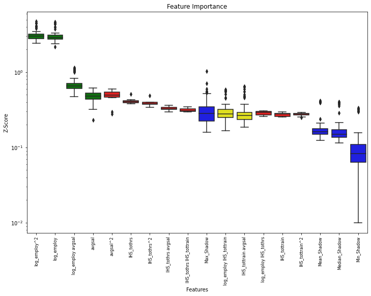

```python
# Subset to separate independent from dependent variables
Temp_QuantInt_Y = Jtrain_TV['log_sales']
Temp_QuantInt_X = Temp_QuantInt

# Boruta Algorithm
Feature_Selector = BorutaShap(importance_measure = 'shap', classification = False)
Feature_Selector.fit(Temp_QuantInt_X, Temp_QuantInt_Y, n_trials = 100, random_state = 0)
Feature_Selector.plot(which_features = 'all')
```

### Mallow's Cp — Qualt. Interactions

```python
def MallowCp(result, base):

    #Compute Cp
    return(sum(result.resid**2)/base.mse_resid - result.nobs + 2*result.params.size)

def Mallow_Brute(Y, Z, Base, data):

    print("This function might take an extended period of time to run.")

    # Create a DataFrame to store the results
    results = pd.DataFrame(["IVs", "P", "CP"])
    count = 0

    for i in range(2, Z.shape[1]+1):

        # Compute every possible subset given p
        combo = list(itertools.combinations(Z.columns, i))

        for j in (combo):
            # fit model and compute CP
            mod = smf.ols(formula = 'Y ~ Z.loc[:,j]', data = data).fit()
            cp = MallowCp(mod, Base)

            # Store values
            results = results.append({"IVs": j, "p": i, "CP": cp}, ignore_index = True)

            # This can take a very long time to run
            # I can keep track of my function by adding a count
            #count+= 1
            #print(count)

    # Find distance from p and CP for each value
    results["distance"] = np.abs(results.p-results.CP)
    return(results)
```

```python
## First round of MCp: Qualitative
Temp_Y = Jtrain_TV['log_sales']
Temp_Y.reset_index(drop = True, inplace = True)
Temp_X = Temp_QualtInt

Model = smf.ols(formula='Temp_Y ~ Temp_X', data = Temp_QualtInt)
Results = Model.fit()
Y_Pred= Results.fittedvalues
Results = Mallow_Brute(Temp_Y, Temp_X, Results, Temp_QualtInt)

# Finding model with combination of least paramaters and distance
Results_Trim = Results.copy()
Results_Trim.sort_values(["distance"], axis = 0, ascending = True).head(15)
```

```
This function might take an extended period of time to run.
```

|  | 0 | CP | IVs | p | distance |
| --- | --- | --- | --- | --- | --- |
| 841 | NaN | 7.001344 | (union, grant, d89, d88, union grant, union d8... | 7.0 | 0.001344 |
| 842 | NaN | 7.001344 | (union, grant, d89, d88, union grant, union d8... | 7.0 | 0.001344 |
| 899 | NaN | 7.001344 | (union, d89, d88, union grant, union d89, gran... | 7.0 | 0.001344 |
| 250 | NaN | 4.004360 | (union, union d88, grant d88, d89 d88) | 4.0 | 0.004360 |
| 392 | NaN | 4.991841 | (union, grant, d89, union d89, d89 d88) | 5.0 | 0.008159 |
| 704 | NaN | 6.010916 | (union, d89, d88, union grant, union d88, gran... | 6.0 | 0.010916 |
| 452 | NaN | 4.980060 | (union, d89, union grant, union d89, d89 d88) | 5.0 | 0.019940 |
| 656 | NaN | 6.026638 | (union, grant, d89, union d89, union d88, gran... | 6.0 | 0.026638 |
| 655 | NaN | 6.026638 | (union, grant, d89, union d89, union d88, gran... | 6.0 | 0.026638 |
| 730 | NaN | 6.026638 | (union, d89, union d89, union d88, grant d89, ... | 6.0 | 0.026638 |
| 714 | NaN | 5.968500 | (union, d89, d88, union d89, grant d89, d89 d88) | 6.0 | 0.031500 |
| 710 | NaN | 5.967780 | (union, d89, d88, union d89, union d88, grant ... | 6.0 | 0.032220 |
| 384 | NaN | 4.965466 | (union, grant, d89, union grant, union d89) | 5.0 | 0.034534 |
| 851 | NaN | 7.037674 | (union, grant, d89, d88, union d89, union d88,... | 7.0 | 0.037674 |
| 850 | NaN | 7.037674 | (union, grant, d89, d88, union d89, union d88,... | 7.0 | 0.037674 |

```python
Results_Trim.iloc[841,2]
```

```
('union', 'grant', 'd89', 'd88', 'union grant', 'union d89', 'grant d89')
```

### Mallow's Cp — Quant.-Qualt. and Qualt.-Qualt. Interactions

```python
## Second round of MCp: Quant*Qualt and Qualt*Qualt
Temp_Y = Jtrain_TV['log_sales']
Temp_Y.reset_index(drop = True, inplace = True)
Temp_X = Temp_QuantQualtInt

Model = smf.ols(formula='Temp_Y ~ Temp_X', data = Temp_QuantQualtInt)
Results = Model.fit()
Y_Pred= Results.fittedvalues
Results = Mallow_Brute(Temp_Y, Temp_X, Results, Temp_QuantQualtInt)

# Finding model with combination of least paramaters and distance
Results_Trim = Results.copy()
Results_Trim = Results_Trim[(Results_Trim['p']) < 12]
Results_Trim.sort_values(["distance"], axis = 0, ascending = True).head(15)
```

```
This function might take an extended period of time to run.
```

|  | 0 | CP | IVs | p | distance |
| --- | --- | --- | --- | --- | --- |
| 58927 | NaN | 11.009276 | (log_employ union, log_employ grant, log_emplo... | 11.0 | 0.009276 |
| 58679 | NaN | 11.063967 | (log_employ union, log_employ grant, log_emplo... | 11.0 | 0.063967 |
| 58647 | NaN | 11.068226 | (log_employ union, log_employ grant, log_emplo... | 11.0 | 0.068226 |
| 60682 | NaN | 11.093752 | (log_employ union, log_employ d89, log_employ ... | 11.0 | 0.093752 |
| 58662 | NaN | 10.890875 | (log_employ union, log_employ grant, log_emplo... | 11.0 | 0.109125 |
| 60680 | NaN | 11.110437 | (log_employ union, log_employ d89, log_employ ... | 11.0 | 0.110437 |
| 58681 | NaN | 11.118903 | (log_employ union, log_employ grant, log_emplo... | 11.0 | 0.118903 |
| 60643 | NaN | 11.149411 | (log_employ union, log_employ d89, log_employ ... | 11.0 | 0.149411 |
| 58674 | NaN | 10.845310 | (log_employ union, log_employ grant, log_emplo... | 11.0 | 0.154690 |
| 59983 | NaN | 11.216802 | (log_employ union, log_employ grant, log_emplo... | 11.0 | 0.216802 |
| 60886 | NaN | 11.291553 | (log_employ union, log_employ d89, log_employ ... | 11.0 | 0.291553 |
| 60852 | NaN | 11.304240 | (log_employ union, log_employ d89, log_employ ... | 11.0 | 0.304240 |
| 58947 | NaN | 11.312440 | (log_employ union, log_employ grant, log_emplo... | 11.0 | 0.312440 |
| 58925 | NaN | 11.359696 | (log_employ union, log_employ grant, log_emplo... | 11.0 | 0.359696 |
| 52384 | NaN | 9.633193 | (log_employ union, log_employ grant, log_emplo... | 10.0 | 0.366807 |

```python
Results_Trim.iloc[58927,2]
```

```
('log_employ union',
 'log_employ grant',
 'log_employ d89',
 'log_employ d88',
 'IHS_tothrs union',
 'IHS_tothrs d89',
 'IHS_tothrs d88',
 'IHS_tottrain grant',
 'IHS_tottrain d89',
 'avgsal union',
 'avgsal d88')
```

### Boruta Algorithm: Quant.-Qualt. Interactions

```
3 attributes confirmed important: ['log_employ union', 'log_employ d89', 'log_employ d88']
6 attributes confirmed unimportant: ['IHS_tottrain grant', 'IHS_tothrs d89', 'IHS_tothrs union', 'log_employ grant', 'avgsal d88', 'IHS_tottrain d89']
2 tentative attributes remains: ['IHS_tothrs d88', 'avgsal union']
```

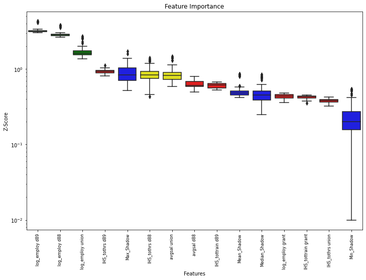

```python
# Subset to separate independent from dependent variables
Temp_QuantInt_Y = Jtrain_TV['log_sales']
Temp_QuantInt_X = Temp_QuantQualtInt[['log_employ union','log_employ grant','log_employ d89',
                                       'log_employ d88','IHS_tothrs union','IHS_tothrs d89',
                                       'IHS_tothrs d88','IHS_tottrain grant','IHS_tottrain d89',
                                       'avgsal union','avgsal d88']]

# Boruta Algorithm
Feature_Selector = BorutaShap(importance_measure = 'shap', classification = False)
Feature_Selector.fit(Temp_QuantInt_X, Temp_QuantInt_Y, n_trials = 100, random_state = 0)
Feature_Selector.plot(which_features = 'all')
```

### Merging Results of Variable Selections

```python
## Higher Order := HOd
## HighOr_A := Base + Quant interactions
HOd_A = pd.concat([Jtrain_Base,
                      Temp_QuantInt[['log_employ avgsal', 'log_employ^2', 'log_employ IHS_tottrain',
                                     'IHS_tottrain avgsal']]], axis = 1)

## HighOr_B := Base + Qualt I.
HOd_B = pd.concat([Jtrain_Base,
                      Temp_QualtInt[['union grant', 'union d89', 'grant d89']]], axis = 1)

## HighOr_C := Base + Qualt I. + Quant I.
HOd_C = pd.concat([Jtrain_Base,
                      Temp_QuantInt[['log_employ avgsal', 'log_employ^2', 'log_employ IHS_tottrain',
                                     'IHS_tottrain avgsal']],
                      Temp_QualtInt[['union grant', 'union d89', 'grant d89']]], axis = 1)

## HighOr_D := Base + Qualt I. + Quant I. + Qualt*Quant I.
## This one is mostly for the hell of it.
HOd_D = pd.concat([HOd_C,
                   Temp_QuantQualtInt[['log_employ union', 'log_employ d89', 'log_employ d88',
                                      'IHS_tothrs d88', 'avgsal union']]], axis = 1)
```

## Initial Model Construction

### Firm and Time Indexing

```python
Jtrain_Base = Jtrain_Base.set_index(['fcode','year'], drop = False)
HOd_A = HOd_A.set_index(['fcode','year'], drop = False)
HOd_B = HOd_B.set_index(['fcode','year'], drop = False)
HOd_C = HOd_C.set_index(['fcode','year'], drop = False)
HOd_D = HOd_D.set_index(['fcode','year'], drop = False)
```

### Pooled Model

```python
## Baseline
PLD_Model_Base_X = Jtrain_Base.drop(columns = ['log_sales', 'year', 'fcode'])
PLD_Model_Base_Y = Jtrain_Base[['log_sales']]

PLD_Model_Base = plm.PooledOLS.from_formula('PLD_Model_Base_Y ~ 1 + PLD_Model_Base_X',
                    data = Jtrain_Base).fit()


## Higher-order A
PLD_Model_HOd_A_X = HOd_A.drop(columns = ['log_sales', 'year', 'fcode'])
PLD_Model_HOd_A_Y = HOd_A['log_sales']

PLD_Model_HOd_A = plm.PooledOLS.from_formula('PLD_Model_HOd_A_Y ~ 1 + PLD_Model_HOd_A_X',
                    data = HOd_A).fit()


## Higher-order B
PLD_Model_HOd_B_X = HOd_B.drop(columns = ['log_sales', 'year', 'fcode'])
PLD_Model_HOd_B_Y = HOd_B['log_sales']

PLD_Model_HOd_B = plm.PooledOLS.from_formula('PLD_Model_HOd_B_Y ~ 1 + PLD_Model_HOd_B_X',
                    data = HOd_B).fit()


## Higher-order C
PLD_Model_HOd_C_X = HOd_C.drop(columns = ['log_sales', 'year', 'fcode'])
PLD_Model_HOd_C_Y = HOd_C['log_sales']

PLD_Model_HOd_C = plm.PooledOLS.from_formula('PLD_Model_HOd_C_Y ~ 1 + PLD_Model_HOd_C_X',
                    data = HOd_B).fit()


## Higher-order D
PLD_Model_HOd_D_X = HOd_D.drop(columns = ['log_sales', 'year', 'fcode'])
PLD_Model_HOd_D_Y = HOd_D['log_sales']

PLD_Model_HOd_D = plm.PooledOLS.from_formula('PLD_Model_HOd_D_Y ~ 1 + PLD_Model_HOd_D_X',
                    data = HOd_D).fit()
```

```python
## Baseline pooled fit results
print(f'{PLD_Model_Base} \n \n')
```

```
                          PooledOLS Estimation Summary
================================================================================
Dep. Variable:       PLD_Model_Base_Y   R-squared:                        0.5987
Estimator:                  PooledOLS   R-squared (Between):              0.6250
No. Observations:                 432   R-squared (Within):               0.2329
Date:                Thu, Dec 01 2022   R-squared (Overall):              0.5987
Time:                        13:52:25   Log-likelihood                   -430.78
Cov. Estimator:            Unadjusted
                                        F-statistic:                      78.893
Entities:                         144   P-value                           0.0000
Avg Obs:                       3.0000   Distribution:                   F(8,423)
Min Obs:                       3.0000
Max Obs:                       3.0000   F-statistic (robust):             78.893
                                        P-value                           0.0000
Time periods:                       3   Distribution:                   F(8,423)
Avg Obs:                       144.00
Min Obs:                       144.00
Max Obs:                       144.00

                                  Parameter Estimates
=======================================================================================
                     Parameter  Std. Err.     T-stat    P-value    Lower CI    Upper CI
---------------------------------------------------------------------------------------
Intercept               12.389     0.1579     78.438     0.0000      12.078      12.699
PLD_Model_Base_X[0]     0.6390     0.0366     17.443     0.0000      0.5670      0.7110
PLD_Model_Base_X[1]    -0.0894     0.0228    -3.9214     0.0001     -0.1342     -0.0446
PLD_Model_Base_X[2]     0.0862     0.0270     3.1943     0.0015      0.0331      0.1392
PLD_Model_Base_X[3]  2.383e-05  5.023e-06     4.7435     0.0000   1.395e-05    3.37e-05
PLD_Model_Base_X[4]     0.3623     0.0821     4.4122     0.0000      0.2009      0.5238
PLD_Model_Base_X[5]    -0.0547     0.0998    -0.5478     0.5841     -0.2508      0.1415
PLD_Model_Base_X[6]     0.0388     0.0825     0.4700     0.6386     -0.1234      0.2009
PLD_Model_Base_X[7]     0.0343     0.0819     0.4186     0.6757     -0.1267      0.1953
=======================================================================================
```

```python
## Higher-order pooled fit results
## Only uncomment one at a time if you know what's good for you.
print(f'{PLD_Model_HOd_A} \n \n')
print(f'{PLD_Model_HOd_B} \n \n')
print(f'{PLD_Model_HOd_C} \n \n')
print(f'{PLD_Model_HOd_D} \n \n')
```

```
                          PooledOLS Estimation Summary
================================================================================
Dep. Variable:      PLD_Model_HOd_A_Y   R-squared:                        0.6051
Estimator:                  PooledOLS   R-squared (Between):              0.6337
No. Observations:                 432   R-squared (Within):               0.2069
Date:                Thu, Dec 01 2022   R-squared (Overall):              0.6051
Time:                        13:52:25   Log-likelihood                   -427.31
Cov. Estimator:            Unadjusted
                                        F-statistic:                      53.509
Entities:                         144   P-value                           0.0000
Avg Obs:                       3.0000   Distribution:                  F(12,419)
Min Obs:                       3.0000
Max Obs:                       3.0000   F-statistic (robust):             53.509
                                        P-value                           0.0000
Time periods:                       3   Distribution:                  F(12,419)
Avg Obs:                       144.00
Min Obs:                       144.00
Max Obs:                       144.00

                                   Parameter Estimates
=========================================================================================
                       Parameter  Std. Err.     T-stat    P-value    Lower CI    Upper CI
-----------------------------------------------------------------------------------------
Intercept                 12.178     0.5377     22.649     0.0000      11.121      13.235
PLD_Model_HOd_A_X[0]      0.8492     0.2419     3.5101     0.0005      0.3736      1.3247
PLD_Model_HOd_A_X[1]     -0.0712     0.0241    -2.9485     0.0034     -0.1186     -0.0237
PLD_Model_HOd_A_X[2]     -0.1107     0.1009    -1.0966     0.2735     -0.3090      0.0877
PLD_Model_HOd_A_X[3]   2.776e-05  2.027e-05     1.3695     0.1716  -1.209e-05   6.761e-05
PLD_Model_HOd_A_X[4]      0.3655     0.0822     4.4473     0.0000      0.2039      0.5270
PLD_Model_HOd_A_X[5]     -0.0466     0.0997    -0.4678     0.6402     -0.2425      0.1493
PLD_Model_HOd_A_X[6]      0.0252     0.0825     0.3050     0.7605     -0.1370      0.1873
PLD_Model_HOd_A_X[7]      0.0343     0.0817     0.4194     0.6751     -0.1264      0.1949
PLD_Model_HOd_A_X[8]   -2.87e-07  5.657e-06    -0.0507     0.9596  -1.141e-05   1.083e-05
PLD_Model_HOd_A_X[9]     -0.0431     0.0296    -1.4588     0.1454     -0.1012      0.0150
PLD_Model_HOd_A_X[10]     0.0507     0.0197     2.5686     0.0106      0.0119      0.0895
PLD_Model_HOd_A_X[11] -9.169e-07  2.994e-06    -0.3062     0.7596  -6.803e-06   4.969e-06
=========================================================================================


                          PooledOLS Estimation Summary
```

[output cut: 109 more lines]

```
PLD_Model_HOd_D_X[6]      0.1509     0.2957     0.5102     0.6102     -0.4305      0.7322
PLD_Model_HOd_D_X[7]      0.1607     0.3029     0.5306     0.5960     -0.4347      0.7561
PLD_Model_HOd_D_X[8]  -2.282e-06  5.853e-06    -0.3898     0.6969  -1.379e-05   9.224e-06
PLD_Model_HOd_D_X[9]     -0.0461     0.0298    -1.5466     0.1227     -0.1047      0.0125
PLD_Model_HOd_D_X[10]     0.0569     0.0207     2.7478     0.0063      0.0162      0.0976
PLD_Model_HOd_D_X[11] -6.876e-07   3.03e-06    -0.2269     0.8206  -6.644e-06   5.269e-06
PLD_Model_HOd_D_X[12]     0.0553     0.2203     0.2512     0.8018     -0.3777      0.4883
PLD_Model_HOd_D_X[13]    -0.0059     0.1748    -0.0338     0.9731     -0.3495      0.3377
PLD_Model_HOd_D_X[14]     0.2660     0.2020     1.3165     0.1887     -0.1312      0.6631
PLD_Model_HOd_D_X[15]    -0.0685     0.0868    -0.7895     0.4303     -0.2391      0.1021
PLD_Model_HOd_D_X[16]    -0.0448     0.0822    -0.5452     0.5859     -0.2063      0.1167
PLD_Model_HOd_D_X[17]    -0.0252     0.0776    -0.3255     0.7450     -0.1777      0.1272
PLD_Model_HOd_D_X[18]    -0.0042     0.0368    -0.1130     0.9101     -0.0765      0.0682
PLD_Model_HOd_D_X[19]  2.875e-05  1.732e-05     1.6598     0.0977  -5.299e-06    6.28e-05
=========================================================================================
```

## Fixed Effects Model

```python
FE_Model_Base = plm.PanelOLS.from_formula('PLD_Model_Base_Y ~ 1 + PLD_Model_Base_X + EntityEffects',
                                          drop_absorbed = True, data = Jtrain_Base).fit()

FE_Model_HOd_A = plm.PanelOLS.from_formula('PLD_Model_HOd_A_Y ~ 1 + PLD_Model_HOd_A_X + EntityEffects',
                                           drop_absorbed = True, data = HOd_A).fit()

FE_Model_HOd_B = plm.PanelOLS.from_formula('PLD_Model_HOd_B_Y ~ 1 + PLD_Model_HOd_B_X + EntityEffects',
                                           drop_absorbed = True, data = HOd_B).fit()

FE_Model_HOd_C = plm.PanelOLS.from_formula('PLD_Model_HOd_C_Y ~ 1 + PLD_Model_HOd_C_X + EntityEffects',
                                           drop_absorbed = True, data = HOd_C).fit()

FE_Model_HOd_D = plm.PanelOLS.from_formula('PLD_Model_HOd_D_Y ~ 1 + PLD_Model_HOd_D_X + EntityEffects',
                                           drop_absorbed = True, data = HOd_D).fit()
```

```python
## Baseline FE fit results
print(f'{FE_Model_Base} \n \n')
```

```
                          PanelOLS Estimation Summary
================================================================================
Dep. Variable:       PLD_Model_Base_Y   R-squared:                        0.2752
Estimator:                   PanelOLS   R-squared (Between):              0.5662
No. Observations:                 432   R-squared (Within):               0.2752
Date:                Thu, Dec 01 2022   R-squared (Overall):              0.5467
Time:                        14:40:40   Log-likelihood                    25.554
Cov. Estimator:            Unadjusted
                                        F-statistic:                      15.243
Entities:                         144   P-value                           0.0000
Avg Obs:                       3.0000   Distribution:                   F(7,281)
Min Obs:                       3.0000
Max Obs:                       3.0000   F-statistic (robust):             15.243
                                        P-value                           0.0000
Time periods:                       3   Distribution:                   F(7,281)
Avg Obs:                       144.00
Min Obs:                       144.00
Max Obs:                       144.00

                                  Parameter Estimates
=======================================================================================
                     Parameter  Std. Err.     T-stat    P-value    Lower CI    Upper CI
---------------------------------------------------------------------------------------
Intercept               12.348     0.3338     36.990     0.0000      11.691      13.005
PLD_Model_Base_X[0]     0.5874     0.0815     7.2036     0.0000      0.4269      0.7479
PLD_Model_Base_X[1]    -0.0283     0.0168    -1.6825     0.0936     -0.0614      0.0048
PLD_Model_Base_X[2]     0.0328     0.0204     1.6099     0.1085     -0.0073      0.0729
PLD_Model_Base_X[3]  3.812e-05  1.211e-05     3.1480     0.0018   1.428e-05   6.196e-05
PLD_Model_Base_X[5]    -0.0175     0.0556    -0.3142     0.7536     -0.1269      0.0920
PLD_Model_Base_X[6]     0.0076     0.0452     0.1678     0.8669     -0.0814      0.0966
PLD_Model_Base_X[7]     0.0095     0.0373     0.2558     0.7983     -0.0639      0.0830
=======================================================================================

F-test for Poolability: 15.034
P-value: 0.0000
Distribution: F(143,281)

Included effects: Entity
```

```python
## Higher-order FE fit results
## Only uncomment one at a time if you know what's good for you.
#print(f'{FE_Model_HOd_A} \n \n')
#print(f'{FE_Model_HOd_B} \n \n')
#print(f'{FE_Model_HOd_C} \n \n')
#print(f'{FE_Model_HOd_D} \n \n')
```

### Random Effects Model

```python
RE_Model_Base = plm.RandomEffects.from_formula('PLD_Model_Base_Y ~ 1 + PLD_Model_Base_X',
                                               data = Jtrain_Base).fit()

RE_Model_HOd_A = plm.RandomEffects.from_formula('PLD_Model_HOd_A_Y ~ 1 + PLD_Model_HOd_A_X',
                                                data = HOd_A).fit()

RE_Model_HOd_B = plm.RandomEffects.from_formula('PLD_Model_HOd_B_Y ~ 1 + PLD_Model_HOd_B_X',
                                                data = HOd_B).fit()

RE_Model_HOd_C = plm.RandomEffects.from_formula('PLD_Model_HOd_C_Y ~ 1 + PLD_Model_HOd_C_X',
                                                data = HOd_C).fit()

RE_Model_HOd_D = plm.RandomEffects.from_formula('PLD_Model_HOd_D_Y ~ 1 + PLD_Model_HOd_D_X',
                                                data = HOd_D).fit()
```

```python
## Baseline RE fit results
print(f'{RE_Model_Base} \n \n')
```

```
                        RandomEffects Estimation Summary
================================================================================
Dep. Variable:       PLD_Model_Base_Y   R-squared:                        0.4377
Estimator:              RandomEffects   R-squared (Between):              0.6160
No. Observations:                 432   R-squared (Within):               0.2706
Date:                Thu, Dec 01 2022   R-squared (Overall):              0.5929
Time:                        13:05:08   Log-likelihood                   -62.380
Cov. Estimator:            Unadjusted
                                        F-statistic:                      41.152
Entities:                         144   P-value                           0.0000
Avg Obs:                       3.0000   Distribution:                   F(8,423)
Min Obs:                       3.0000
Max Obs:                       3.0000   F-statistic (robust):             41.152
                                        P-value                           0.0000
Time periods:                       3   Distribution:                   F(8,423)
Avg Obs:                       144.00
Min Obs:                       144.00
Max Obs:                       144.00

                                  Parameter Estimates
=======================================================================================
                     Parameter  Std. Err.     T-stat    P-value    Lower CI    Upper CI
---------------------------------------------------------------------------------------
Intercept               12.269     0.1998     61.406     0.0000      11.877      12.662
PLD_Model_Base_X[0]     0.6477     0.0457     14.168     0.0000      0.5579      0.7376
PLD_Model_Base_X[1]    -0.0405     0.0157    -2.5756     0.0103     -0.0715     -0.0096
PLD_Model_Base_X[2]     0.0418     0.0190     2.2059     0.0279      0.0046      0.0791
PLD_Model_Base_X[3]  2.709e-05  6.833e-06     3.9638     0.0001   1.365e-05   4.052e-05
PLD_Model_Base_X[4]     0.3904     0.1334     2.9275     0.0036      0.1283      0.6525
PLD_Model_Base_X[5]    -0.0157     0.0533    -0.2948     0.7683     -0.1205      0.0890
PLD_Model_Base_X[6]     0.0214     0.0392     0.5464     0.5850     -0.0556      0.0984
PLD_Model_Base_X[7]     0.0150     0.0360     0.4177     0.6764     -0.0557      0.0858
=======================================================================================
```

```python
## Higher-order RE fit results
## Only uncomment one at a time if you know what's good for you.
print(f'{RE_Model_HOd_A} \n \n')
print(f'{RE_Model_HOd_B} \n \n')
print(f'{RE_Model_HOd_C} \n \n')
print(f'{RE_Model_HOd_D} \n \n')
```

```
                        RandomEffects Estimation Summary
================================================================================
Dep. Variable:      PLD_Model_HOd_A_Y   R-squared:                        0.4430
Estimator:              RandomEffects   R-squared (Between):              0.6168
No. Observations:                 432   R-squared (Within):               0.2808
Date:                Thu, Dec 01 2022   R-squared (Overall):              0.5943
Time:                        13:05:08   Log-likelihood                   -59.979
Cov. Estimator:            Unadjusted
                                        F-statistic:                      27.773
Entities:                         144   P-value                           0.0000
Avg Obs:                       3.0000   Distribution:                  F(12,419)
Min Obs:                       3.0000
Max Obs:                       3.0000   F-statistic (robust):             27.773
                                        P-value                           0.0000
Time periods:                       3   Distribution:                  F(12,419)
Avg Obs:                       144.00
Min Obs:                       144.00
Max Obs:                       144.00

                                   Parameter Estimates
=========================================================================================
                       Parameter  Std. Err.     T-stat    P-value    Lower CI    Upper CI
-----------------------------------------------------------------------------------------
Intercept                 12.443     0.5508     22.592     0.0000      11.361      13.526
PLD_Model_HOd_A_X[0]      0.5379     0.2473     2.1751     0.0302      0.0518      1.0240
PLD_Model_HOd_A_X[1]     -0.0267     0.0171    -1.5563     0.1204     -0.0604      0.0070
PLD_Model_HOd_A_X[2]     -0.0525     0.0643    -0.8159     0.4150     -0.1789      0.0739
PLD_Model_HOd_A_X[3]   3.518e-05  2.261e-05     1.5562     0.1204  -9.256e-06   7.962e-05
PLD_Model_HOd_A_X[4]      0.3988     0.1338     2.9812     0.0030      0.1358      0.6617
PLD_Model_HOd_A_X[5]     -0.0070     0.0540    -0.1293     0.8972     -0.1131      0.0991
PLD_Model_HOd_A_X[6]      0.0173     0.0394     0.4392     0.6607     -0.0601      0.0947
PLD_Model_HOd_A_X[7]      0.0161     0.0361     0.4477     0.6546     -0.0548      0.0871
PLD_Model_HOd_A_X[8]  -1.731e-06  6.289e-06    -0.2752     0.7833  -1.409e-05   1.063e-05
PLD_Model_HOd_A_X[9]      0.0132     0.0308     0.4299     0.6675     -0.0473      0.0738
PLD_Model_HOd_A_X[10]     0.0225     0.0124     1.8131     0.0705     -0.0019      0.0468
PLD_Model_HOd_A_X[11] -4.792e-07  1.938e-06    -0.2472     0.8049  -4.289e-06   3.331e-06
=========================================================================================


                        RandomEffects Estimation Summary
```

[output cut: 109 more lines]

```
PLD_Model_HOd_D_X[6]     -0.0445     0.1459    -0.3052     0.7604     -0.3314      0.2423
PLD_Model_HOd_D_X[7]      0.0527     0.1359     0.3878     0.6984     -0.2145      0.3199
PLD_Model_HOd_D_X[8]  -3.614e-06  6.746e-06    -0.5357     0.5924  -1.687e-05   9.646e-06
PLD_Model_HOd_D_X[9]      0.0040     0.0326     0.1213     0.9035     -0.0601      0.0680
PLD_Model_HOd_D_X[10]     0.0204     0.0133     1.5383     0.1247     -0.0057      0.0466
PLD_Model_HOd_D_X[11] -6.122e-07  2.006e-06    -0.3051     0.7604  -4.556e-06   3.332e-06
PLD_Model_HOd_D_X[12]     0.1118     0.1064     1.0511     0.2938     -0.0973      0.3210
PLD_Model_HOd_D_X[13]    -0.0122     0.0778    -0.1569     0.8754     -0.1651      0.1407
PLD_Model_HOd_D_X[14]     0.0145     0.1095     0.1325     0.8947     -0.2008      0.2298
PLD_Model_HOd_D_X[15]     0.0808     0.1212     0.6668     0.5053     -0.1575      0.3191
PLD_Model_HOd_D_X[16]     0.0180     0.0408     0.4418     0.6588     -0.0622      0.0982
PLD_Model_HOd_D_X[17]    -0.0041     0.0346    -0.1176     0.9065     -0.0721      0.0640
PLD_Model_HOd_D_X[18]    -0.0075     0.0168    -0.4507     0.6525     -0.0405      0.0254
PLD_Model_HOd_D_X[19]  1.385e-05  2.584e-05     0.5358     0.5924  -3.695e-05   6.465e-05
=========================================================================================
```

## Model Evaluation and Analysis

## Determining Random vs. Fixed Effects

```python
## Hausman test of FE vs. RE
results_fe = FE_Model_Base
#results_fe = FE_Model_HOd_D
b_fe = results_fe.params
b_fe_cov = results_fe.cov

results_re = RE_Model_Base
#results_re = RE_Model_HOd_D
b_re = results_re.params
b_re_cov = results_re.cov

## (I) find overlapping coefficients:
common_coef = set(results_fe.params.index).intersection(results_re.params.index)

## (II) calculate differences between FE and RE:
b_diff = np.array(results_fe.params[common_coef] - results_re.params[common_coef])
df = len(b_diff)
b_diff.reshape((df, 1))
b_cov_diff = np.array(b_fe_cov.loc[common_coef, common_coef] -
                      b_re_cov.loc[common_coef, common_coef])
b_cov_diff.reshape((df, df))

## (III) calculate test statistic:
stat = abs(np.transpose(b_diff) @ np.linalg.inv(b_cov_diff) @ b_diff)
pval = 1 - stats.chi2.cdf(stat, df)

print(f'stat: {stat}\n')
print(f'pval: {pval}\n')

## Fail to reject H0. Pref model is random effects over fixed effects
## for all base and higher order.
```

```
stat: 4.069949476555195

pval: 0.8507578362481317
```

```python
## Hausman results (F-stat, p-val.)
    ## Baseline --> 4.070, 0.851
    ## HOd_A -->  9.278, 0.679
    ## HOd_B -->  7.138, 0.788
    ## HOd_C --> 12.789, 0.619
    ## HOd_D --> 19.296, 0.503
```

### Determining Optimality: Coefs. Neq. Zero (F-Stat & P-Value)

```python
## Pooled model
    ## Baseline --> 78.893, 0.0000
    ## HOd_A --> 53.509, 0.0000
    ## HOd_B --> 57.481, 0.0000
    ## HOd_C --> 42.919, 0.0000
    ## HOd_D --> 32.213, 0.0000

## Random effects
    ## Baseline --> 41.152, 0.0000
    ## HOd_A --> 27.773, 0.0000
    ## HOd_B --> 29.872, 0.0000
    ## HOd_C --> 22.195, 0.0000
    ## HOd_D --> 16.389, 0.0000
```

In the same vein as the Hausman tests, we may turn to the F-stats of our families of pooled and random effect models to see if the competitors might be trimmed down. However, we are able to reject the joint null hypothesis of our parameter coefficients being defined as zero in favor of our non-zero estimated paramters.

### Determining Optimality: R-Squared (Between)

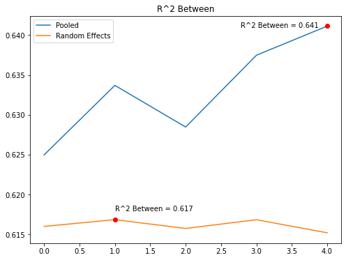

```
0.6411346811497265
0.6168486282105481
```

```python
DO1_Pooled = np.array([PLD_Model_Base.rsquared_between, PLD_Model_HOd_A.rsquared_between,
                       PLD_Model_HOd_B.rsquared_between, PLD_Model_HOd_C.rsquared_between,
                       PLD_Model_HOd_D.rsquared_between])
DO1_RndEff = np.array([RE_Model_Base.rsquared_between, RE_Model_HOd_A.rsquared_between,
                       RE_Model_HOd_B.rsquared_between, RE_Model_HOd_C.rsquared_between,
                       RE_Model_HOd_D.rsquared_between])

plt.figure(figsize = (8,6))
plt.title("R^2 Between")
plt.plot(range(len(DO1_Pooled)), DO1_Pooled, label = 'Pooled')
plt.plot(range(len(DO1_RndEff)), DO1_RndEff, label = 'Random Effects')
plt.plot(4, max(DO1_Pooled), 'ro')
plt.plot(1, max(DO1_RndEff), 'ro')
plt.annotate('R^2 Between = 0.641', (2.78, 0.641))
plt.annotate('R^2 Between = 0.617', (1, 0.618))
plt.legend()
plt.show()

print(max(DO1_Pooled))
print(max(DO1_RndEff))
```

Before any analysis, the R2 (Between) score is defined as the proportion of variance between individuals (i.e. Panel units) that can be explained by the model. With that being said, we can see that the pooled models have a higher average R2 (Between) score: the most optimal in this context is the full pooled model at approximately 0.641. However, many occurences of statistical insignificance leave the baseline pooled model at a R2 (Between) of 0.625 as our remaining option.

### Determining Optimality: R-Squared (Within)

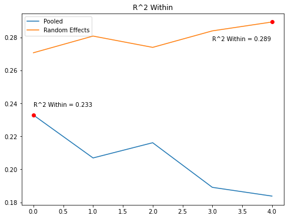

```python
DO2_Pooled = np.array([PLD_Model_Base.rsquared_within, PLD_Model_HOd_A.rsquared_within,
                       PLD_Model_HOd_B.rsquared_within, PLD_Model_HOd_C.rsquared_within,
                       PLD_Model_HOd_D.rsquared_within])
DO2_RndEff = np.array([RE_Model_Base.rsquared_within, RE_Model_HOd_A.rsquared_within,
                       RE_Model_HOd_B.rsquared_within, RE_Model_HOd_C.rsquared_within,
                       RE_Model_HOd_D.rsquared_within])

plt.figure(figsize = (8,6))
plt.title("R^2 Within")
plt.plot(range(len(DO2_Pooled)), DO2_Pooled, label = 'Pooled')
plt.plot(range(len(DO2_RndEff)), DO2_RndEff, label = 'Random Effects')
plt.plot(0, max(DO2_Pooled), 'ro')
plt.plot(4, max(DO2_RndEff), 'ro')
plt.annotate('R^2 Within = 0.233', (0, 0.238))
plt.annotate('R^2 Within = 0.289', (3, 0.278))
plt.legend()
plt.show()
```

Given the previous definition for R2 (Between), the definition of R2 (Within) is not too surprising: it is the proportion of variance within individuals that can be explained by the model. Contrary to our previous result, the most optimal model is — on the surface — the full random effects model at a R2 (Within) of 0.289. This may be due to the high-dimensionality of the full model, since it contains a total 21 parameters.

However, the parameter estimates for the full random effects model are majority statistically insignificant. With this understanding, we must acknowledge that the baseline random effects model is the most realistic option here. While slightly less variance-explanatory at a R2 (Within) of 0.271, the baseline random effects model possesses a higher proportion of statistically signiciant variables. That is, we give up a small amount of intra-panel variance explanation for a less noisy model.

### Determining Optimality: R-Squared (Overall)

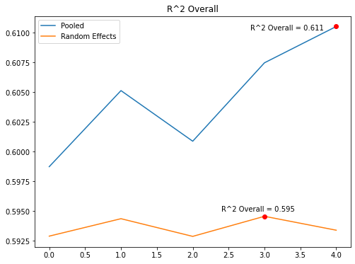

```python
DO3_Pooled = np.array([PLD_Model_Base.rsquared_overall, PLD_Model_HOd_A.rsquared_overall,
                       PLD_Model_HOd_B.rsquared_overall, PLD_Model_HOd_C.rsquared_overall,
                       PLD_Model_HOd_D.rsquared_overall])
DO3_RndEff = np.array([RE_Model_Base.rsquared_overall, RE_Model_HOd_A.rsquared_overall,
                       RE_Model_HOd_B.rsquared_overall, RE_Model_HOd_C.rsquared_overall,
                       RE_Model_HOd_D.rsquared_overall])

plt.figure(figsize = (8,6))
plt.title("R^2 Overall")
plt.plot(range(len(DO3_Pooled)), DO3_Pooled, label = 'Pooled')
plt.plot(range(len(DO3_RndEff)), DO3_RndEff, label = 'Random Effects')
plt.plot(4, max(DO3_Pooled), 'ro')
plt.plot(3, max(DO3_RndEff), 'ro')
plt.annotate('R^2 Overall = 0.611', (2.8, 0.6102))
plt.annotate('R^2 Overall = 0.595', (2.4, 0.595))
plt.legend()
plt.show()
```

Looking to the weighted average of R2 (Between) and R2 (Within), we can see that the most optimal model in terms of R2 (Overall) is the full pooled model at 0.611. However, the graphical representation is partially misleading; this is the fault of the author who forgot to adjust the y-axes limits before doing the write-up.

Ultimately, the combination of statistical insignificance rife within the full models and the razor-thin margin moving down the models (as seen in the R2 (Between) discussion) leaves us with the baseline pooled model at 0.599, at best.

### Determining Optimality: Log-Likelihood

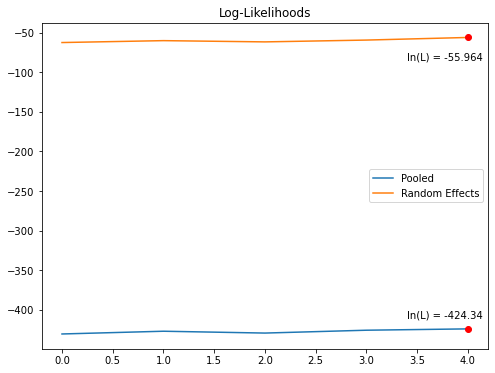

```python
DO5_Pooled = np.array([-430.78, -427.31, -429.63, -426.03, -424.34])
DO5_RndEff = np.array([-62.380, -59.979, -61.552, -59.261, -55.964])

plt.figure(figsize = (8,6))
plt.title("Log-Likelihoods")
plt.plot(range(len(DO5_Pooled)), DO5_Pooled, label = 'Pooled')
plt.plot(range(len(DO5_RndEff)), DO5_RndEff, label = 'Random Effects')
plt.plot(4, round(max(DO5_Pooled), 8), 'ro')
plt.plot(4, round(max(DO5_RndEff), 8), 'ro')
plt.annotate('ln(L) = -424.34', (3.4, -410))
plt.annotate('ln(L) = -55.964', (3.4, -85))
plt.legend()
plt.show()
```

Included in the interest of completeness, the log-likelihood value comparisons do little to shed light on within the model families. However, we can conclude that the random effects model family is superior in this regard.

### Determining Optimality: AIC & BIC

```python
def AIC (SSE, N, K):
    return (np.log(SSE/N) + (2*K)/N)

def BIC (SSE, N, K):
    return (np.log(SSE/N) + (np.log(N)*K)/N)
```

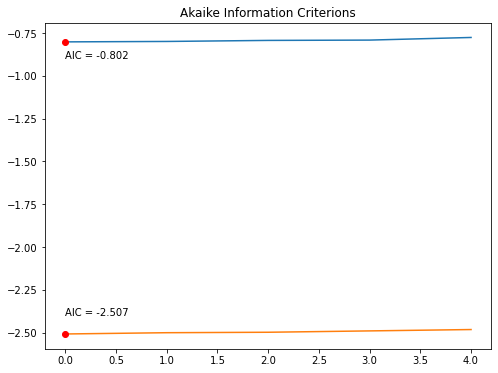

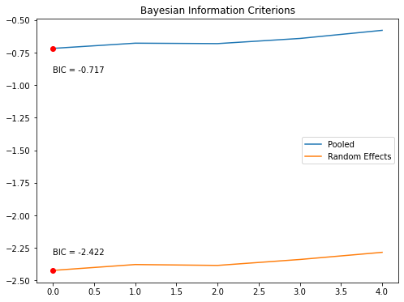

```python
DO6_Pooled = np.array([AIC(PLD_Model_Base.resid_ss, PLD_Model_Base.nobs, len(PLD_Model_Base.params)),
                      AIC(PLD_Model_HOd_A.resid_ss, PLD_Model_HOd_A.nobs, len(PLD_Model_HOd_A.params)),
                      AIC(PLD_Model_HOd_B.resid_ss, PLD_Model_HOd_B.nobs, len(PLD_Model_HOd_B.params)),
                      AIC(PLD_Model_HOd_C.resid_ss, PLD_Model_HOd_C.nobs, len(PLD_Model_HOd_C.params)),
                      AIC(PLD_Model_HOd_D.resid_ss, PLD_Model_HOd_D.nobs, len(PLD_Model_HOd_D.params))])

DO6_RndEff = np.array([AIC(RE_Model_Base.resid_ss, RE_Model_Base.nobs, len(RE_Model_Base.params)),
                      AIC(RE_Model_HOd_A.resid_ss, RE_Model_HOd_A.nobs, len(RE_Model_HOd_A.params)),
                      AIC(RE_Model_HOd_B.resid_ss, RE_Model_HOd_B.nobs, len(RE_Model_HOd_B.params)),
                      AIC(RE_Model_HOd_C.resid_ss, RE_Model_HOd_C.nobs, len(RE_Model_HOd_C.params)),
                      AIC(RE_Model_HOd_D.resid_ss, RE_Model_HOd_D.nobs, len(RE_Model_HOd_D.params))])

DO7_Pooled = np.array([BIC(PLD_Model_Base.resid_ss, PLD_Model_Base.nobs, len(PLD_Model_Base.params)),
                      BIC(PLD_Model_HOd_A.resid_ss, PLD_Model_HOd_A.nobs, len(PLD_Model_HOd_A.params)),
                      BIC(PLD_Model_HOd_B.resid_ss, PLD_Model_HOd_B.nobs, len(PLD_Model_HOd_B.params)),
                      BIC(PLD_Model_HOd_C.resid_ss, PLD_Model_HOd_C.nobs, len(PLD_Model_HOd_C.params)),
                      BIC(PLD_Model_HOd_D.resid_ss, PLD_Model_HOd_D.nobs, len(PLD_Model_HOd_D.params))])

DO7_RndEff = np.array([BIC(RE_Model_Base.resid_ss, RE_Model_Base.nobs, len(RE_Model_Base.params)),
                      BIC(RE_Model_HOd_A.resid_ss, RE_Model_HOd_A.nobs, len(RE_Model_HOd_A.params)),
                      BIC(RE_Model_HOd_B.resid_ss, RE_Model_HOd_B.nobs, len(RE_Model_HOd_B.params)),
                      BIC(RE_Model_HOd_C.resid_ss, RE_Model_HOd_C.nobs, len(RE_Model_HOd_C.params)),
                      BIC(RE_Model_HOd_D.resid_ss, RE_Model_HOd_D.nobs, len(RE_Model_HOd_D.params))])

plt.figure(figsize = (8,6))
plt.title("Akaike Information Criterions")
plt.plot(range(len(DO6_Pooled)), DO6_Pooled, label = 'Pooled')
plt.plot(range(len(DO6_RndEff)), DO6_RndEff, label = 'Random Effects')
plt.plot(0, round(min(DO6_Pooled), 8), 'ro')
plt.plot(0, round(min(DO6_RndEff), 8), 'ro')
plt.annotate('AIC = -0.802', (0, -0.9))
plt.annotate('AIC = -2.507', (0, -2.4))
plt.show()

plt.figure(figsize = (8,6))
plt.title("Bayesian Information Criterions")
plt.plot(range(len(DO7_Pooled)), DO7_Pooled, label = 'Pooled')
plt.plot(range(len(DO7_RndEff)), DO7_RndEff, label = 'Random Effects')
plt.plot(0, round(min(DO7_Pooled), 8), 'ro')
plt.plot(0, round(min(DO7_RndEff), 8), 'ro')
plt.annotate('BIC = -0.717', (0, -0.9))
plt.annotate('BIC = -2.422', (0, -2.3))
plt.legend()
plt.show()
```

While the above results were either vague or horribly inconclusive, the AIC and BIC metrics provide the first major reasonable measure of comparison. Here, we can see that the random effects model handidly beats out the pooled effects family. The baseline random effects model takes the place of most optimal among its siblings at -2.507 and -2.422 for AIC and BIC, respectively.

### Final Determination of Optimality

Summary of above results:

```
1. Hausman: Random effects existant.
2. Non-zero param. coefs: Rejected in favor of alternative for pooled and random effects.
3. R2 (Between): Baseline pooled; inconclusive.
4. R2 (Within): Baseline random effects.
5. R2 (Overall): Inconclusive.
6. AIC & BIC: Baseline random effects
```

In conclusion, it appears that the baseline random effects model is the most optimal and the model of preference. However, it cannot be stressed enough that this is essentially "optimality by default". Neither the random or pooled families of models displayed signiciant statistical value at any major level: even the baseline models would only be of minor use in a real-world scenario. This result could be explained by three situations:

```
1. The effect of training subsidies on annual sales over time is minimal;
2. The success of businesses in the real-world economy is incredibly noisy and difficult to fit a strong model on;
3. Failure on part of the authors.
```

In the end, all three could be occurring simultaneously, or none at all. While the baseline random effects model has won out in the end, it would be more accurate to describe it as the least worst model.